# Tugas 1 — Pengantar Analisis Data Kategori

Latihan Analisis Data dengan R dan Quarto

Mahasiswa

Nurhikmah

NIM

241061005

Kode Tugas

ADK1-070181B0

**Tujuan tugas.** Gunakan kembali konsep dan fungsi R yang telah dibahas pada Pertemuan 1 untuk mengenali struktur data kategori, membuat ringkasan deskriptif, memvisualisasikan data, dan menjelaskan insight secara hati-hati.

**CatatanPola kerja**

Ikuti pola kelas: **predict → run → inspect → explain**.

Pada setiap bagian diberikan **sedikit petunjuk kode**.  
Jika diminta menjelaskan atau menuliskan interpretasi, gunakan kotak **Jawaban Anda** yang telah disediakan.

# 1 1. Mengenali Data

Gunakan R untuk melihat beberapa baris awal, struktur data, dan nama variabel.

**TipPetunjuk kode**

```r
head(...)
str(...)
names(...)
```

Ganti `...` dengan objek data yang digunakan.

```r
head(data)
```

```
  RecordID     ProgramStudi Gender DeviceUtama ModaBelajar   Kepuasan
1   645961   Sains Aktuaria      P  Smartphone     Diskusi      Cukup
2   889698 Sistem Informasi      P      Tablet       Video       Puas
3   287269 Sistem Informasi      L      Tablet     Diskusi Tidak Puas
4   561195       Sains Data      P      Tablet     Praktik       Puas
5   505351 Sistem Informasi      P      Tablet     Diskusi      Cukup
6   705184 Sistem Informasi      L      Tablet     Diskusi       Puas
  IntensitasBelajar DurasiBelajarJam       PaketID
1            Sedang              5.1 ADK1-070181B0
2            Rendah              4.6 ADK1-070181B0
3            Tinggi              7.2 ADK1-070181B0
4            Sedang              5.7 ADK1-070181B0
5            Sedang              8.8 ADK1-070181B0
6            Sedang              8.0 ADK1-070181B0
```

```r
str(data)
```

```
'data.frame':   101 obs. of  9 variables:
 $ RecordID         : int  645961 889698 287269 561195 505351 705184 103934 654440 925009 525305 ...
 $ ProgramStudi     : chr  "Sains Aktuaria" "Sistem Informasi" "Sistem Informasi" "Sains Data" ...
 $ Gender           : chr  "P" "P" "L" "P" ...
 $ DeviceUtama      : chr  "Smartphone" "Tablet" "Tablet" "Tablet" ...
 $ ModaBelajar      : chr  "Diskusi" "Video" "Diskusi" "Praktik" ...
 $ Kepuasan         : chr  "Cukup" "Puas" "Tidak Puas" "Puas" ...
 $ IntensitasBelajar: chr  "Sedang" "Rendah" "Tinggi" "Sedang" ...
 $ DurasiBelajarJam : num  5.1 4.6 7.2 5.7 8.8 8 8.2 4.5 8.2 3.6 ...
 $ PaketID          : chr  "ADK1-070181B0" "ADK1-070181B0" "ADK1-070181B0" "ADK1-070181B0" ...
```

```r
names(data)
```

```
[1] "RecordID"          "ProgramStudi"      "Gender"
[4] "DeviceUtama"       "ModaBelajar"       "Kepuasan"
[7] "IntensitasBelajar" "DurasiBelajarJam"  "PaketID"
```

Lengkapi tabel berikut.

| Variabel | Jenis Variabel | Alasan Singkat |
| --- | --- | --- |
| RecordID | Identifier (nominal) | Angka unik tiap responden, hanya label, tidak bermakna kuantitatif |
| ProgramStudi | Nominal | Kategori sejajar (4 program studi) tanpa urutan tingkatan |
| Gender | Nominal | Kategori sejajar (L/P) tanpa urutan tingkatan |
| DeviceUtama | Nominal | Jenis perangkat, tidak ada tingkatan alami antar kategori |
| ModaBelajar | Nominal | Cara belajar, kategori sejajar tanpa urutan |
| Kepuasan | Ordinal | Ada tingkatan jelas: Tidak Puas < Cukup < Puas < Sangat Puas |
| IntensitasBelajar | Ordinal | Ada tingkatan jelas: Rendah < Sedang < Tinggi |
| DurasiBelajarJam | Numerik (rasio) | Berupa angka desimal (jam) yang bisa dijumlah/dirata-ratakan |

Jawab singkat:

1. Variabel mana yang merupakan identifier?
2. Variabel mana yang bersifat ordinal?
3. Mengapa kode angka belum tentu berarti data numerik?

**Jawaban Anda**

1. `RecordID` adalah identifier karena hanya berfungsi sebagai penanda unik tiap responden, bukan besaran yang bisa dihitung.
2. Variabel ordinal pada data ini adalah `Kepuasan` (Tidak Puas–Cukup–Puas–Sangat Puas) dan `IntensitasBelajar` (Rendah–Sedang–Tinggi), karena kategorinya memiliki urutan tingkatan.
3. Kode angka belum tentu berarti data numerik karena angka tersebut bisa hanya berfungsi sebagai label kategori (misalnya kode program studi atau ID responden); operasi matematis seperti rata-rata atau selisih terhadap angka semacam itu tidak memiliki makna.

# 2 2. Menyiapkan Data Kategori

Variabel latihan Anda:

```r
cat("Nominal :", identitas$nominal_utama[1], "\n")
```

```
Nominal : DeviceUtama
```

```r
cat("Ordinal :", identitas$ordinal_utama[1], "\n")
```

```
Ordinal : Kepuasan
```

```r
cat("Urutan  :", identitas$urutan_ordinal[1], "\n")
```

```
Urutan  : Tidak Puas|Cukup|Puas|Sangat Puas
```

Lakukan hal berikut:

1. ubah variabel nominal menjadi factor;
2. ubah variabel ordinal menjadi ordered factor;
3. periksa level kategorinya.

**TipPetunjuk kode**

Untuk nominal:

```r
factor(...)
levels(...)
```

Untuk ordinal:

```r
factor(..., levels = ..., ordered = TRUE)
```

```r
nominal_var <- identitas$nominal_utama[1]
ordinal_var <- identitas$ordinal_utama[1]
urutan <- strsplit(identitas$urutan_ordinal[1], "\\|")[[1]]

# 1. Ubah variabel nominal menjadi factor
data[[nominal_var]] <- factor(data[[nominal_var]])
levels(data[[nominal_var]])
```

```
[1] "Laptop"     "Smartphone" "Tablet"
```

```r
# 2. Ubah variabel ordinal menjadi ordered factor
data[[ordinal_var]] <- factor(data[[ordinal_var]], levels = urutan, ordered = TRUE)
levels(data[[ordinal_var]])
```

```
[1] "Tidak Puas"  "Cukup"       "Puas"        "Sangat Puas"
```

Tuliskan satu kalimat: **mengapa urutan level ordinal perlu ditetapkan dengan benar?**

**Jawaban Anda**

Urutan level ordinal perlu ditetapkan dengan benar agar R (dan analisis lanjutan seperti perbandingan atau pengurutan kategori) memahami tingkatan sebenarnya dari data, misalnya bahwa “Sangat Puas” lebih tinggi daripada “Puas”, sehingga interpretasi dan visualisasi tetap akurat dan tepat.

# 3 3. Quality Control Awal

Lakukan pemeriksaan sederhana terhadap:

- struktur data;
- level/kategori;
- missing value;
- konsistensi penulisan kategori.

**TipPetunjuk kode**

Beberapa pola fungsi yang dapat digunakan:

```r
str(...)
levels(...)
unique(...)
is.na(...)
colSums(...)
```

Pilih fungsi yang sesuai dengan tujuan pemeriksaan Anda.

```r
str(data)
```

```
'data.frame':   101 obs. of  9 variables:
 $ RecordID         : int  645961 889698 287269 561195 505351 705184 103934 654440 925009 525305 ...
 $ ProgramStudi     : chr  "Sains Aktuaria" "Sistem Informasi" "Sistem Informasi" "Sains Data" ...
 $ Gender           : chr  "P" "P" "L" "P" ...
 $ DeviceUtama      : Factor w/ 3 levels "Laptop","Smartphone",..: 2 3 3 3 3 3 3 3 3 3 ...
 $ ModaBelajar      : chr  "Diskusi" "Video" "Diskusi" "Praktik" ...
 $ Kepuasan         : Ord.factor w/ 4 levels "Tidak Puas"<"Cukup"<..: 2 3 1 3 2 3 3 3 2 1 ...
 $ IntensitasBelajar: chr  "Sedang" "Rendah" "Tinggi" "Sedang" ...
 $ DurasiBelajarJam : num  5.1 4.6 7.2 5.7 8.8 8 8.2 4.5 8.2 3.6 ...
 $ PaketID          : chr  "ADK1-070181B0" "ADK1-070181B0" "ADK1-070181B0" "ADK1-070181B0" ...
```

```r
levels(data[[nominal_var]])
```

```
[1] "Laptop"     "Smartphone" "Tablet"
```

```r
levels(data[[ordinal_var]])
```

```
[1] "Tidak Puas"  "Cukup"       "Puas"        "Sangat Puas"
```

```r
unique(data$ModaBelajar)
```

```
[1] "Diskusi" "Video"   "Praktik" "Buku"
```

```r
colSums(is.na(data))
```

```
         RecordID      ProgramStudi            Gender       DeviceUtama
                0                 0                 0                 1
      ModaBelajar          Kepuasan IntensitasBelajar  DurasiBelajarJam
                0                 2                 1                 0
          PaketID
                0
```

Tuliskan **dua temuan singkat** dari pemeriksaan tersebut.

**Jawaban Anda**

1. Terdapat beberapa nilai hilang (missing value): 1 pada `DeviceUtama`, 2 pada `Kepuasan`, dan 1 pada `IntensitasBelajar`, sehingga perlu diperhatikan saat membuat ringkasan agar tidak salah interpretasi.
2. Penulisan kategori pada seluruh variabel kategorik (`DeviceUtama`, `ModaBelajar`, `Kepuasan`, `IntensitasBelajar`) sudah konsisten, tidak ditemukan variasi ejaan atau kapitalisasi yang berbeda untuk kategori yang sama.

# 4 4. Frekuensi dan Proporsi

Sebelum menjalankan kode, prediksi:

> Menurut Anda, kategori mana yang paling banyak muncul pada variabel nominal Anda?

**Prediksi Anda**

Menurut saya, kategori “Tablet” kemungkinan paling banyak muncul pada variabel `DeviceUtama` karena didasarkan pada pengamatan sekilas pada struktur data awal `(head(data))`, serta tren mahasiswa saat ini yang banyak memanfaatkan tablet untuk kebutuhan kuliah harian.

Setelah itu, buat:

- tabel frekuensi untuk variabel nominal;
- proporsi untuk variabel ordinal.

**TipPetunjuk kode**

```r
table(...)
prop.table(...)
```

Anda dapat menyimpan hasil `table()` ke sebuah objek terlebih dahulu sebelum menghitung proporsi.

```r
# Tabel frekuensi untuk variabel nominal (DeviceUtama)
freq_device <- table(data[[nominal_var]])
freq_device
```

```
    Laptop Smartphone     Tablet
        23         11         66
```

```r
# Proporsi untuk variabel ordinal (Kepuasan)
freq_kepuasan <- table(data[[ordinal_var]])
prop.table(freq_kepuasan)
```

```
 Tidak Puas       Cukup        Puas Sangat Puas
  0.1616162   0.2727273   0.3333333   0.2323232
```

Tuliskan **dua kalimat insight** berdasarkan output.

**Interpretasi Anda**

1. Prediksi saya benar: kategori “Tablet” memang paling banyak muncul pada `DeviceUtama`, yaitu 66 dari 101 responden (sekitar 65%), jauh di atas Laptop (23 responden) dan Smartphone (11 responden).
2. Pada variabel `Kepuasan`, proporsi terbesar berada pada kategori “Puas” (sekitar 33%), diikuti “Cukup” (sekitar 27%) dan “Sangat Puas” (sekitar 23%), sementara “Tidak Puas” adalah proporsi terkecil (sekitar 16%), menunjukkan kecenderungan tingkat kepuasan yang cukup baik secara umum.

# 5 5. Tabel Silang

Pasangan variabel Anda:

```r
x <- identitas$tab_baris[1]
y <- identitas$tab_kolom[1]

cat("Baris :", x, "\n")
```

```
Baris : ModaBelajar
```

```r
cat("Kolom :", y, "\n")
```

```
Kolom : IntensitasBelajar
```

Buat tabel silang untuk kedua variabel tersebut.

Jika diperlukan, tampilkan proporsi per baris untuk membantu membaca pola.

**TipPetunjuk kode**

```r
table(..., ...)
prop.table(..., margin = 1)
```

Lengkapi sendiri objek yang diperlukan.

```r
tabel_silang <- table(data[[x]], data[[y]])
tabel_silang
```

```
          Rendah Sedang Tinggi
  Buku         7     11     10
  Diskusi     12     13     13
  Praktik      5     10      5
  Video        5      4      5
```

```r
# Proporsi per baris
prop.table(tabel_silang, margin = 1)
```

```
             Rendah    Sedang    Tinggi
  Buku    0.2500000 0.3928571 0.3571429
  Diskusi 0.3157895 0.3421053 0.3421053
  Praktik 0.2500000 0.5000000 0.2500000
  Video   0.3571429 0.2857143 0.3571429
```

Tuliskan **satu kalimat** yang menjelaskan pola yang tampak.

**Penting**

Gunakan bahasa deskriptif. Jangan langsung menyimpulkan adanya hubungan signifikan atau sebab-akibat.

# 6 6. Visualisasi Kategorik

Variabel yang divisualisasikan:

```r
v <- identitas$visualisasi[1]
cat("Variabel grafik :", v, "\n")
```

```
Variabel grafik : DeviceUtama
```

Buat **satu grafik batang** seperti yang telah dipelajari pada Pertemuan 1.

**TipPetunjuk kode**

```r
library(ggplot2)

ggplot(..., aes(x = ...)) +
  geom_bar() +
  labs(...)
```

Sesuaikan objek data, variabel, judul, dan label sumbu.

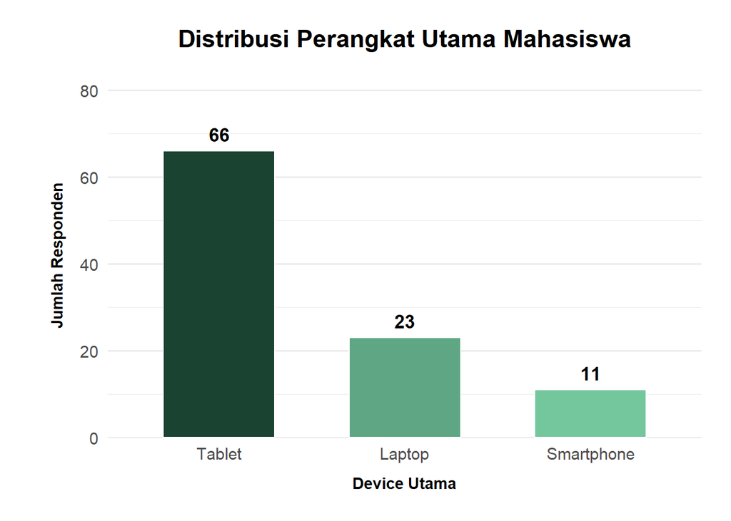

```r
library(ggplot2)
library(forcats)

ggplot(remove_missing(data, vars = v), aes(x = fct_infreq(.data[[v]]), fill = after_stat(count))) +
  geom_bar(width = 0.6, show.legend = FALSE, color = "white", linewidth = 0.5) +
  geom_text(stat = "count", aes(label = after_stat(count)), vjust = -0.7, fontface = "bold", size = 4.5) +
  scale_y_continuous(limits = c(0, 80), breaks = seq(0, 80, 20), expand = expansion(mult = c(0, 0.05))) +
  scale_fill_gradient(low = "#74c69d", high = "#1b4332") +
  labs(title = "Distribusi Perangkat Utama Mahasiswa", x = "Device Utama", y = "Jumlah Responden") +
  theme_minimal(base_size = 14) +
  theme(
    plot.title = element_text(face = "bold", margin = margin(b = 15), hjust = 0.5),
    axis.title.x = element_text(face = "bold", size = 11, hjust = 0.5, margin = margin(t = 10)),
    axis.title.y = element_text(face = "bold", size = 11, hjust = 0.5, margin = margin(r = 10)),
    panel.grid.major.x = element_blank(),
    plot.margin = margin(20, 20, 20, 35)
  )
```

Tuliskan **satu kalimat** interpretasi grafik.

**Interpretasi Anda**

Grafik batang menunjukkan bahwa “Tablet” merupakan perangkat utama yang paling dominan digunakan mahasiswa untuk belajar, jauh melampaui jumlah pengguna Laptop dan Smartphone.

# 7 7. Kesimpulan

Tuliskan **3 poin kesimpulan singkat** berdasarkan hasil analisis.

Setiap kesimpulan harus:

- didukung oleh output yang telah Anda hasilkan;
- menggunakan angka yang relevan;
- ditulis dengan bahasa Anda sendiri;
- tidak menggunakan klaim sebab-akibat.

**Analisis Data Kategori — Tugas 1**  
Predict → Run → Inspect → Explain